# Final: Texas Higher Education Opportunity Project (THEOP)

# Data

Unfortunately, the data does not often include information regarding a student’s high school academics or application essays. In evaluating the results, we take great note of these data constraints.

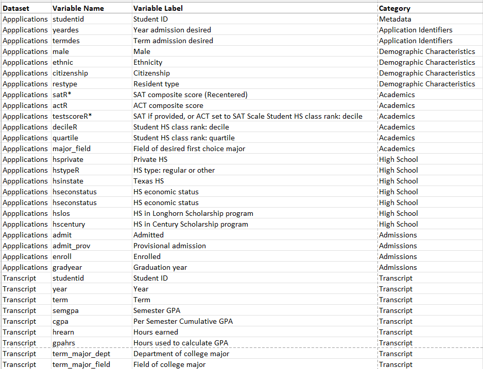

Each record in the application dataset included a response variable “admit” (Institution’s admission decision), was a boolean where “1” indicated the person was admitted.

A sample of the data appears in the following table:

| studentid | yeardes | termdes | male | ethnic | satR | actR | testscoreR | decileR | quartile | major_field | hsprivate | hstypeR | hsinstate | hseconstatus | hslos | hscentury | admit | admit_prov | enroll | gradyear | studentid_uniq | US_Citizen | Texas_resident |
| --- | --- | --- | --- | --- | --- | --- | --- | --- | --- | --- | --- | --- | --- | --- | --- | --- | --- | --- | --- | --- | --- | --- | --- |
| 000004 | 1998 | Fall | 0 | White, Non-Hispanic | 38 | 10 | 38 | Second Decile | Top 25% | AGRICULTURE | Public | Regular | Yes | Upper-middle quartile |  |  | 1 | 0 | 0 |  | am_000004 | 1 | 1 |
| 000005 | 1998 | Fall | 1 | White, Non-Hispanic | 20 |  | 20 | Fifth Decile | Second quartile | NATURAL/PHYSICAL SCIENCES | Public | Regular | Yes | Lower-middle quartile |  |  | 0 | 0 | 0 |  | am_000005 | 1 | 1 |
| 000006 | 1998 | Fall | 1 | White, Non-Hispanic | 66 | 8 | 66 | Top 10% | Top 25% | ENGINEERING/COMPUTER SCIENCE | Public | Regular | Yes | Upper quartile |  |  | 1 | 0 | 0 |  | am_000006 | 1 | 1 |
| 000007 | 1998 | Fall | 1 | White, Non-Hispanic | 27 | 5 | 27 | Third Decile | Second quartile | AGRICULTURE | Public | Regular | Yes | Lower-middle quartile |  |  | 1 | 0 | 1 | 14 | am_000007 | 1 | 1 |
| 000008 | 1998 | Fall | 1 | White, Non-Hispanic | 86 |  | 86 | Second Decile | Top 25% | NATURAL/PHYSICAL SCIENCES | Public | Regular | Yes | Upper quartile |  |  | 1 | 0 | 0 |  | am_000008 | 1 | 1 |
| 000009 | 1998 | Fall | 0 | White, Non-Hispanic | 58 | 11 | 58 | Fifth Decile | Second quartile | NATURAL/PHYSICAL SCIENCES | Public | Regular | Yes | Upper quartile |  |  | 1 | 0 | 0 |  | am_000009 | 1 | 1 |
| 000011 | 1998 | Fall | 1 | Other | 56 |  | 56 | Fourth Decile | Second quartile | SOCIAL SCIENCES | Public | Other | Yes | Upper quartile |  |  | 1 | 0 | 1 |  | am_000011 | 1 | 1 |
| 000012 | 1998 | Fall | 0 | Asian or Pacific Islander | 38 | 9 | 38 | Third Decile | Top 25% | GENERAL STUDIES | Private |  | Yes |  |  |  | 1 | 0 | 0 |  | am_000012 | 1 | 1 |
| 000013 | 1998 | Fall | 0 | Hispanic | 20 | 4 | 20 | Second Decile | Top 25% | ENGINEERING/COMPUTER SCIENCE | Public | Regular | Yes | Lower quartile |  |  | 0 | 0 | 0 |  | am_000013 | 1 | 1 |
| 000014 | 1992 | Fall | 1 | White, Non-Hispanic | 57 |  | 57 | Third Decile | Top 25% | NATURAL/PHYSICAL SCIENCES | Public | Regular | Yes |  |  |  | 1 | 0 | 1 | 7 | am_000014 | 1 | 1 |

[output cut: 15 more lines]

While exploring this data, we made the following observations for the **applications data**:

| variable | complete_rate | n_missing | min | max |
| --- | --- | --- | --- | --- |
| actR | 0.46 | 72133 | 1 | 24 |
| admit | 1.00 | 0 | NA | NA |
| admit_prov | 1.00 | 0 | NA | NA |
| decileR | 1.00 | 0 | NA | NA |
| enroll | 1.00 | 0 | NA | NA |
| ethnic | 1.00 | 50 | NA | NA |
| gradyear | 0.35 | 86914 | 2 | 22 |
| hscentury | 0.32 | 91636 | NA | NA |
| hseconstatus | 0.72 | 38094 | NA | NA |
| hsinstate | 1.00 | 103 | NA | NA |
| hslos | 0.41 | 79635 | NA | NA |
| hsprivate | 0.98 | 2375 | NA | NA |
| hstypeR | 0.91 | 12338 | NA | NA |
| major_field | 1.00 | 2 | NA | NA |
| male | 1.00 | 52 | NA | NA |
| quartile | 1.00 | 10 | NA | NA |
| satR | 1.00 | 0 | 3 | 111 |
| studentid | 1.00 | 0 | NA | NA |
| studentid_uniq | 1.00 | 0 | NA | NA |
| termdes | 1.00 | 0 | NA | NA |
| testscoreR | 1.00 | 0 | 3 | 111 |
| Texas_resident | 1.00 | 0 | NA | NA |
| US_Citizen | 1.00 | 0 | NA | NA |
| yeardes | 1.00 | 0 | 1992 | 2002 |

76% of all the students were admitted to the university.

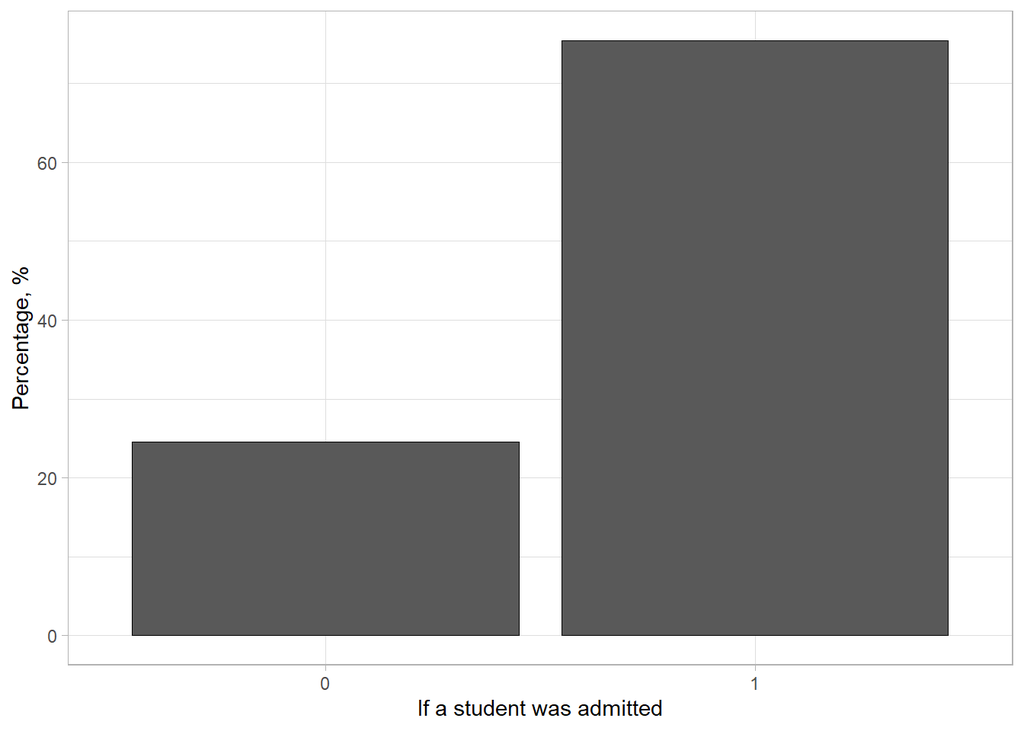

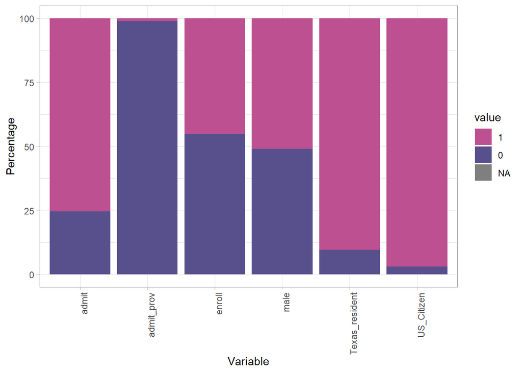

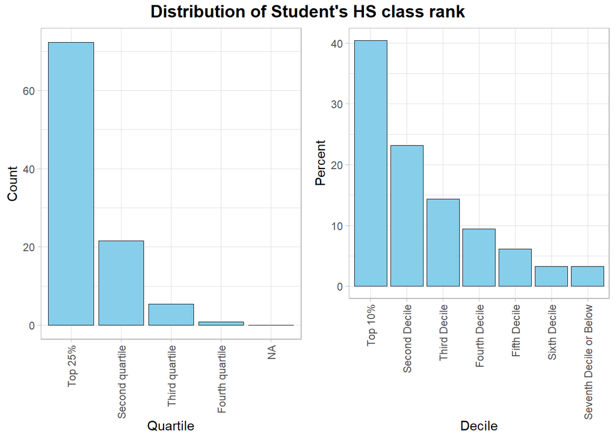

# Transform Data

Students with missing values for `ethnic` variable are combined with “White, Non-Hispanic” students, resulting in cautious estimates of policy effects.

```
## The original levels Black, Non-Hispanic Hispanic American Indian/Alaskan Native Asian or Pacific Islander White, Non-Hispanic International Other None
## have been replaced by Black, Non-Hispanic Hispanic American Indian/Alaskan Native Asian or Pacific Islander International Other White, Non-Hispanic
```

| variable | complete_rate | n_missing | min | max |
| --- | --- | --- | --- | --- |
| admit | 1 | 0 | NA | NA |
| enroll | 1 | 0 | NA | NA |
| ethnic | 1 | 0 | NA | NA |
| hsinstate | 1 | 0 | NA | NA |
| hsprivate | 1 | 0 | NA | NA |
| male | 1 | 0 | NA | NA |
| satR | 1 | 0 | 3 | 111 |
| termdes | 1 | 0 | NA | NA |
| testscoreR | 1 | 0 | 3 | 111 |
| Texas_resident | 1 | 0 | NA | NA |
| top10 | 1 | 0 | NA | NA |
| US_Citizen | 1 | 0 | NA | NA |
| yeardes | 1 | 0 | 1992 | 2002 |

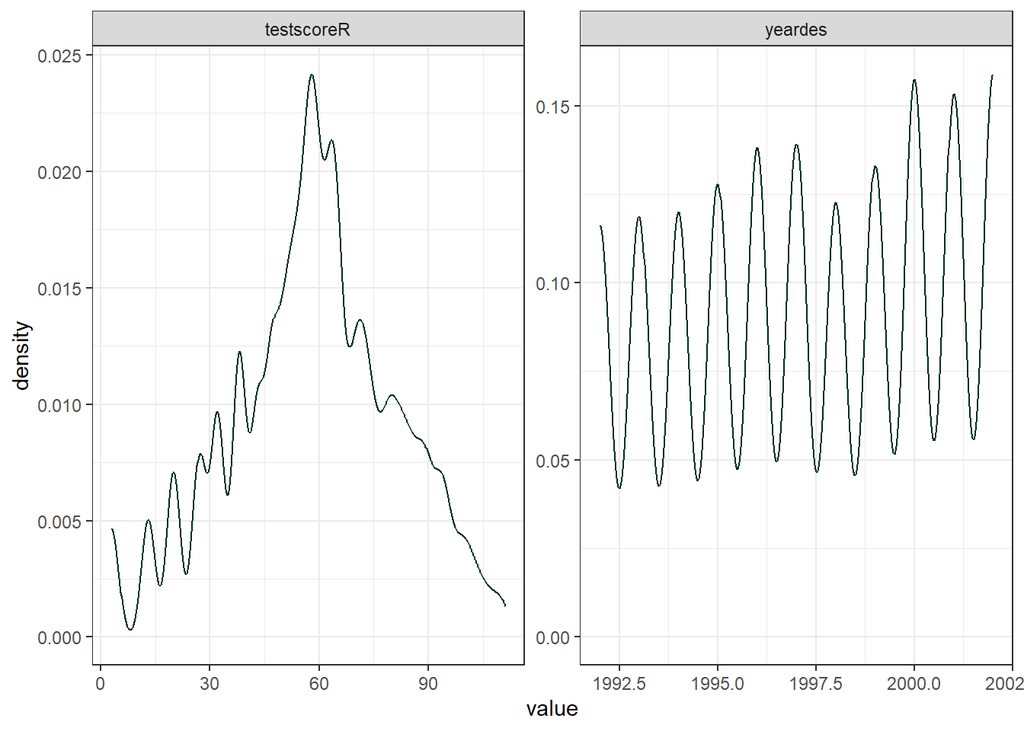

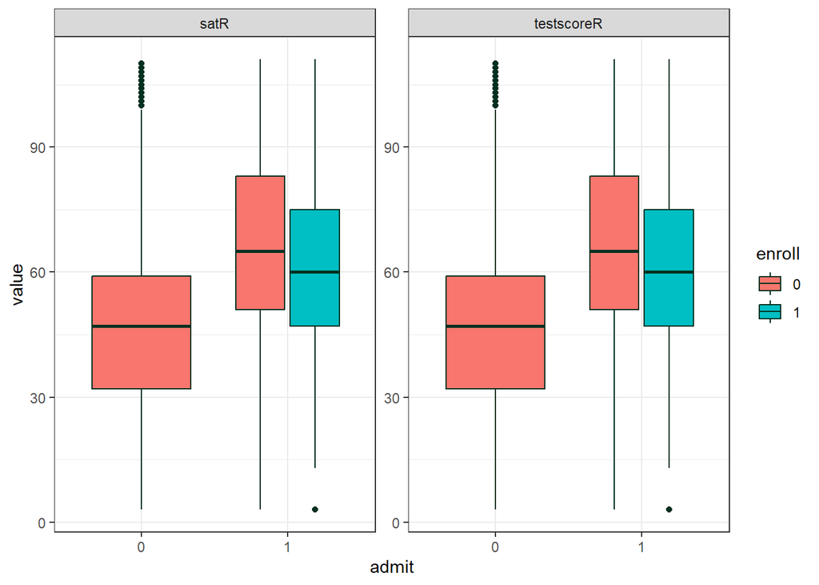

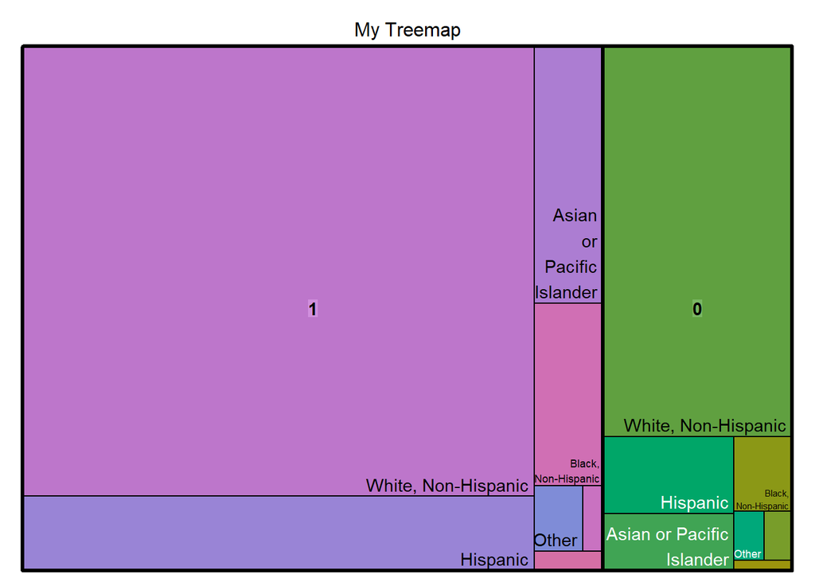

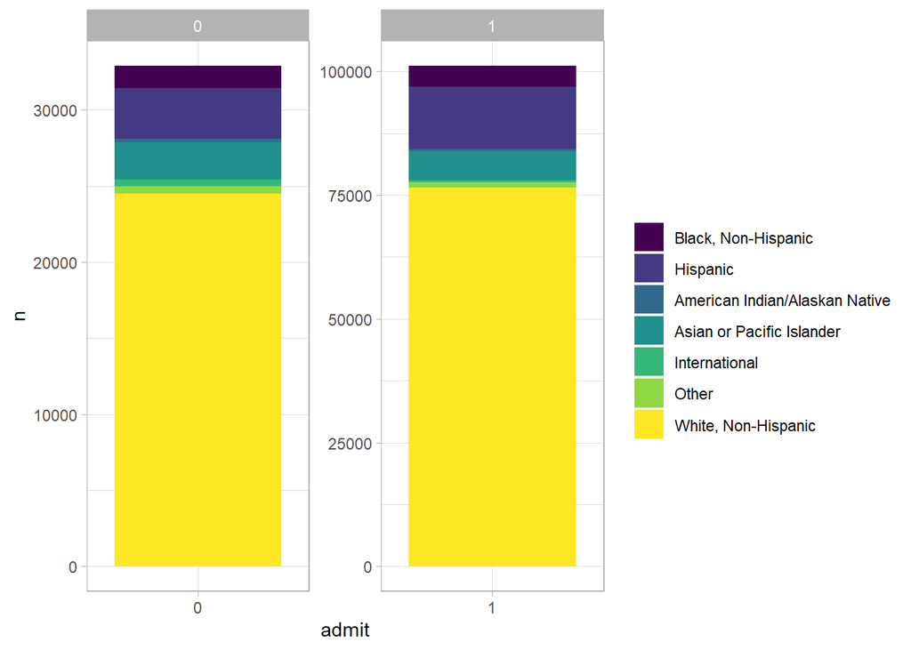

[output not shown]

[output cut: 353 more lines]

[output not shown]

# Models

As the first step, we built the generalized linear model based on the dataset with some variables transformed to categorical from numeric for the time before Fall, 1998.

| variable | complete_rate | n_missing | min | max |
| --- | --- | --- | --- | --- |
| admit | 1 | 0 | NA | NA |
| enroll | 1 | 0 | NA | NA |
| ethnic | 1 | 0 | NA | NA |
| hsinstate | 1 | 0 | NA | NA |
| hsprivate | 1 | 0 | NA | NA |
| male | 1 | 0 | NA | NA |
| satR | 1 | 0 | 3 | 111 |
| termdes | 1 | 0 | NA | NA |
| testscoreR | 1 | 0 | 3 | 111 |
| Texas_resident | 1 | 0 | NA | NA |
| top10 | 1 | 0 | NA | NA |
| US_Citizen | 1 | 0 | NA | NA |
| yeardes | 1 | 0 | 1992 | 1998 |

```
##
## Call:
## glm(formula = admit ~ . - enroll - yeardes - termdes, family = binomial(link = "probit"),
##     data = pre_df)
##
## Deviance Residuals:
##     Min       1Q   Median       3Q      Max
## -3.8936   0.0305   0.1906   0.6786   2.7660
##
## Coefficients: (1 not defined because of singularities)
##                                        Estimate Std. Error z value Pr(>|z|)
## (Intercept)                          -1.0649721  0.0569552 -18.698  < 2e-16 ***
## male1                                -0.1443959  0.0131538 -10.978  < 2e-16 ***
## ethnicHispanic                       -0.0258000  0.0370032  -0.697   0.4857
## ethnicAmerican Indian/Alaskan Native -0.8790031  0.0939285  -9.358  < 2e-16 ***
## ethnicAsian or Pacific Islander      -0.9181691  0.0427157 -21.495  < 2e-16 ***
## ethnicInternational                  -0.4846015  0.0896390  -5.406 6.44e-08 ***
## ethnicOther                          -0.9894696  0.0689488 -14.351  < 2e-16 ***
## ethnicWhite, Non-Hispanic            -0.7983680  0.0325750 -24.509  < 2e-16 ***
## US_Citizen1                           0.0766258  0.0420904   1.821   0.0687 .
## Texas_resident1                       0.7330951  0.0335813  21.830  < 2e-16 ***
## satR                                  0.0282780  0.0003536  79.970  < 2e-16 ***
## testscoreR                                   NA         NA      NA       NA
## top10TRUE                             1.4734079  0.0196313  75.054  < 2e-16 ***
## hsprivatePrivate                     -0.1714509  0.0257750  -6.652 2.89e-11 ***
## hsprivateNone                        -0.2848834  0.0473206  -6.020 1.74e-09 ***
## hsinstateYes                          0.0653105  0.0361204   1.808   0.0706 .
## hsinstateNone                        -0.2056722  0.2039254  -1.009   0.3132
## ---
## Signif. codes:  0 '***' 0.001 '**' 0.01 '*' 0.05 '.' 0.1 ' ' 1
##
## (Dispersion parameter for binomial family taken to be 1)
##
##     Null deviance: 73803  on 69018  degrees of freedom
## Residual deviance: 50413  on 69003  degrees of freedom
## AIC: 50445
##
## Number of Fisher Scoring iterations: 6
```

| Observations | 69019 |
| --- | --- |
| Dependent variable | admit |
| Type | Generalized linear model |
| Family | binomial |
| Link | probit |

| χ(15) | 23390.53 |
| --- | --- |
| Pseudo-R (Cragg-Uhler) | 0.44 |
| Pseudo-R (McFadden) | 0.32 |
| AIC | 50444.85 |
| BIC | 50591.12 |

|  | Est. | S.E. | z val. | p |
| --- | --- | --- | --- | --- |
| (Intercept) | -1.06 | 0.06 | -18.70 | 0.00 |
| male1 | -0.14 | 0.01 | -10.98 | 0.00 |
| ethnicHispanic | -0.03 | 0.04 | -0.70 | 0.49 |
| ethnicAmerican Indian/Alaskan Native | -0.88 | 0.09 | -9.36 | 0.00 |
| ethnicAsian or Pacific Islander | -0.92 | 0.04 | -21.49 | 0.00 |
| ethnicInternational | -0.48 | 0.09 | -5.41 | 0.00 |
| ethnicOther | -0.99 | 0.07 | -14.35 | 0.00 |
| ethnicWhite, Non-Hispanic | -0.80 | 0.03 | -24.51 | 0.00 |
| US_Citizen1 | 0.08 | 0.04 | 1.82 | 0.07 |
| Texas_resident1 | 0.73 | 0.03 | 21.83 | 0.00 |
| satR | 0.03 | 0.00 | 79.97 | 0.00 |
| top10TRUE | 1.47 | 0.02 | 75.05 | 0.00 |
| hsprivatePrivate | -0.17 | 0.03 | -6.65 | 0.00 |
| hsprivateNone | -0.28 | 0.05 | -6.02 | 0.00 |
| hsinstateYes | 0.07 | 0.04 | 1.81 | 0.07 |
| hsinstateNone | -0.21 | 0.20 | -1.01 | 0.31 |

Standard errors: MLE

## Model Results

As it appeared, `ethnic` variable had the most negative effect for the university acceptance. While being Texas resident or being in top 10% could help to be admitted.

The `null deviance` of 7.380338^{4} defined how well the target variable could be predicted by a model with only an intercept term.

The `residual deviance` of 5.041285^{4} defined how well the target variable could be predicted by the AIC model that we fit with the predictor variables listed above. The lower the value, the better the model’s predictions of the response variable.

The p-value associated with this `Chi-Square Statistic` was 0 (less than .05), so the model could be useful.

The Akaike information criterion (`AIC`) was 5.044485^{4}. The lower the AIC value, the better the model’s ability to fit the data.

#### Checking Model Assumptions

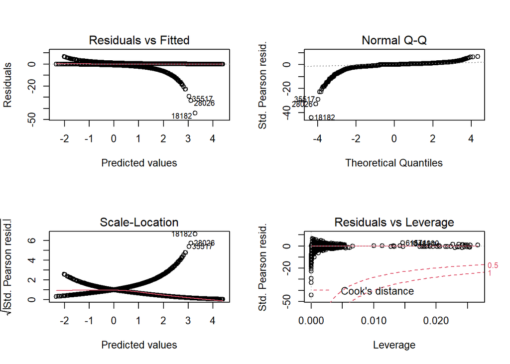

```
##   1   2   3   4   5   6
## "1" "1" "1" "1" "0" "1"
```

The Standardized Residuals plot seems to have a constant variance though there are some outliers.

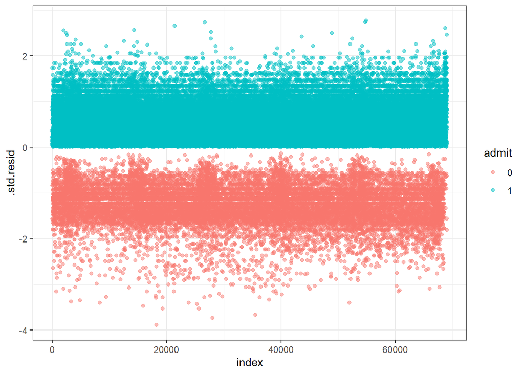

[output not shown]

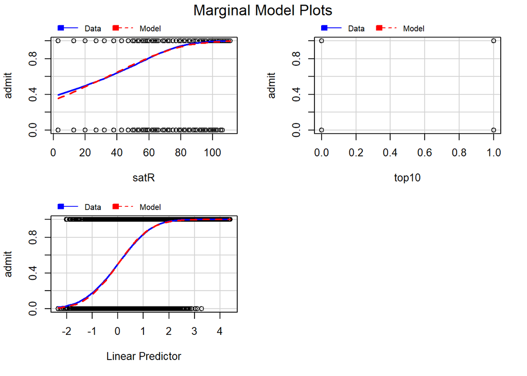

In terms of multicollinearity, all variables have a VIF less than 5. As a result, multicollinearity shouldn’t be a problem for our model.

```
##                    GVIF Df GVIF^(1/(2*Df))
## male           1.051668  1        1.025509
## ethnic         1.994261  6        1.059209
## US_Citizen     1.546489  1        1.243579
## Texas_resident 3.086787  1        1.756926
## satR           1.197600  1        1.094349
## top10          1.018228  1        1.009073
## hsprivate      1.383635  2        1.084564
## hsinstate      3.311345  2        1.348966
```

# Predict